# Reproducible research W2

gustav

November 11, 2018

This assignment will be described in multiple parts. You will need to write a report that answers the questions detailed below. Ultimately, you will need to complete the entire assignment in a single R markdown document that can be processed by knitr and be transformed into an HTML file.

### Loading and preprocessing the data

1. Show any code that is needed to load the data:

```r
data <- read.csv("activity.csv", header = TRUE, na.strings = "NA", sep = ",")
summary(data)
```

```
##      steps                date          interval
##  Min.   :  0.00   2012-10-01:  288   Min.   :   0.0
##  1st Qu.:  0.00   2012-10-02:  288   1st Qu.: 588.8
##  Median :  0.00   2012-10-03:  288   Median :1177.5
##  Mean   : 37.38   2012-10-04:  288   Mean   :1177.5
##  3rd Qu.: 12.00   2012-10-05:  288   3rd Qu.:1766.2
##  Max.   :806.00   2012-10-06:  288   Max.   :2355.0
##  NA's   :2304     (Other)   :15840
```

2. Transform the data if needed / Date to date class / Interval to factor class /

```r
str(data)
```

```
## 'data.frame':    17568 obs. of  3 variables:
##  $ steps   : int  NA NA NA NA NA NA NA NA NA NA ...
##  $ date    : Factor w/ 61 levels "2012-10-01","2012-10-02",..: 1 1 1 1 1 1 1 1 1 1 ...
##  $ interval: int  0 5 10 15 20 25 30 35 40 45 ...
```

```r
head(data)
```

```
##   steps       date interval
## 1    NA 2012-10-01        0
## 2    NA 2012-10-01        5
## 3    NA 2012-10-01       10
## 4    NA 2012-10-01       15
## 5    NA 2012-10-01       20
## 6    NA 2012-10-01       25
```

```r
data$date <- as.Date(data$date, format = "%Y-%m-%d")
data$interval <- factor(data$interval)

NA_values <- is.na(as.character(data$steps))
cleanData <- data[!NA_values,]
head(cleanData)
```

```
##     steps       date interval
## 289     0 2012-10-02        0
## 290     0 2012-10-02        5
## 291     0 2012-10-02       10
## 292     0 2012-10-02       15
## 293     0 2012-10-02       20
## 294     0 2012-10-02       25
```

## What is mean total number of steps taken per day?

1. Calculate the total number of steps taken per day
2. If you do not understand the difference between a histogram and a barplot, research the difference between them. Make a histogram of the total number of steps taken each day
3. Calculate and report the mean and median of the total number of steps taken per day

```r
steps_per_day <- aggregate(steps ~ date, data = cleanData, sum)
colnames(steps_per_day) <- c("date", "steps")

#Total number of steps per day:
head(steps_per_day)
```

```
##         date steps
## 1 2012-10-02   126
## 2 2012-10-03 11352
## 3 2012-10-04 12116
## 4 2012-10-05 13294
## 5 2012-10-06 15420
## 6 2012-10-07 11015
```

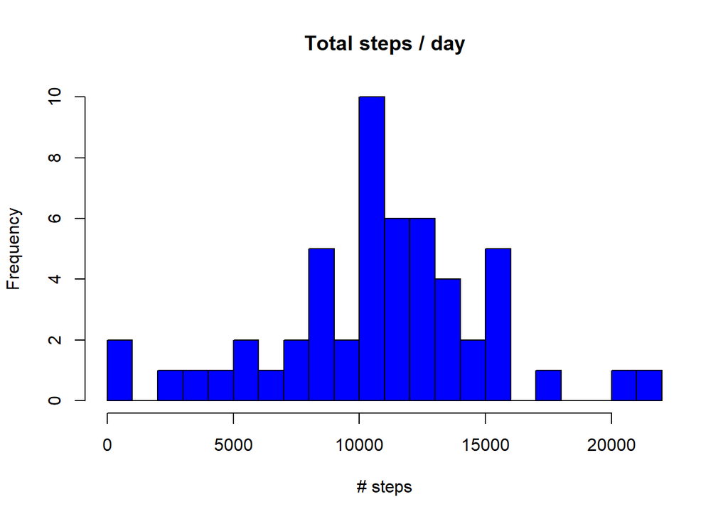

```r
#Histogram
hist(as.numeric(steps_per_day$steps), breaks = 25, col = "blue", xlab = "# steps", main = "Total steps / day")
```

```r
#Mean and median
mean(steps_per_day$steps)
```

```
## [1] 10766.19
```

```r
median(steps_per_day$steps)
```

```
## [1] 10765
```

## What is the average daily activity pattern?

1. Make a time series plot (i.e. type=“l”) of the 5-minute interval (x-axis) and the average number of steps taken, averaged across all days (y-axis)

```r
steps_per_int <- aggregate(steps ~ interval, data = cleanData, FUN = mean)
#steps_per_int <- aggregate(cleanData$steps, by=list(interval=cleanData$interval), FUN=mean)
colnames(steps_per_int) = c("interval", "avg_steps")
head(steps_per_int)
```

```
##   interval avg_steps
## 1        0 1.7169811
## 2        5 0.3396226
## 3       10 0.1320755
## 4       15 0.1509434
## 5       20 0.0754717
## 6       25 2.0943396
```

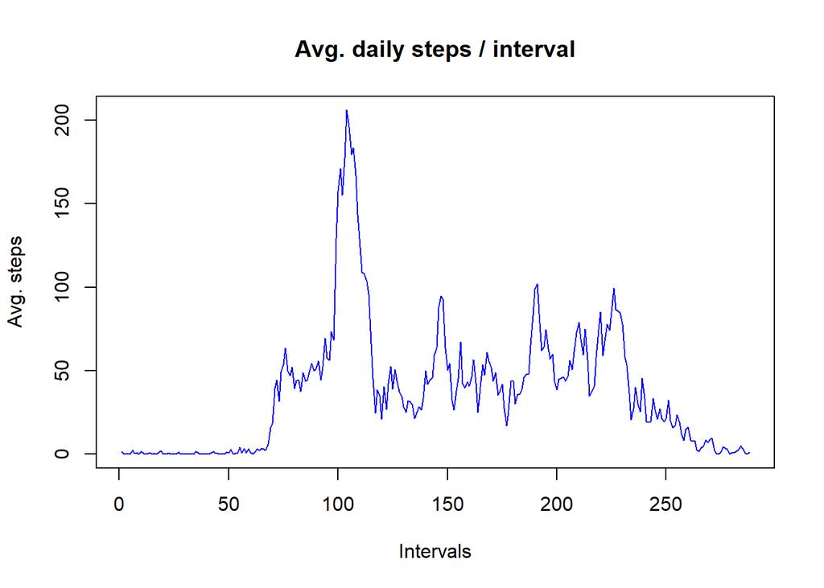

```r
#Time series plot:
plot(as.integer(steps_per_int$interval),steps_per_int$avg_steps, type = "l", xlab = "Intervals", ylab = "Avg. steps", main = "Avg. daily steps / interval", col = "blue")
```

2. Which 5-minute interval, on average across all the days in the dataset, contains the maximum number of steps?

```r
max <- max(steps_per_int$avg_steps)
max
```

```
## [1] 206.1698
```

```r
maxInt <- steps_per_int[steps_per_int$avg_steps == max,]
maxInt
```

```
##     interval avg_steps
## 104      835  206.1698
```

## Imputing missing values

1. Calculate and report the total number of missing values in the dataset (i.e. the total number of rows with NAs)

```r
sum(is.na(as.character(data$steps)))
```

```
## [1] 2304
```

2. Devise a strategy for filling in all of the missing values in the dataset. The strategy does not need to be sophisticated. For example, you could use the mean/median for that day, or the mean for that 5-minute interval, etc.

```r
NA_index <- which(is.na(as.character(data$steps)))
head(NA_index)
```

```
## [1] 1 2 3 4 5 6
```

```r
filled_data <- data
filled_data[NA_index, ]$steps <- unlist(lapply(NA_index, FUN=function(NA_index){
  steps_per_int[data[NA_index,]$interval==steps_per_int$interval,]$avg_steps
}))
```

3. Create a new dataset that is equal to the original dataset but with the missing data filled in.

```r
head(filled_data)
```

```
##       steps       date interval
## 1 1.7169811 2012-10-01        0
## 2 0.3396226 2012-10-01        5
## 3 0.1320755 2012-10-01       10
## 4 0.1509434 2012-10-01       15
## 5 0.0754717 2012-10-01       20
## 6 2.0943396 2012-10-01       25
```

4. Make a histogram of the total number of steps taken each day and Calculate and report the mean and median total number of steps taken per day. Do these values differ from the estimates from the first part of the assignment? What is the impact of imputing missing data on the estimates of the total daily number of steps?

```r
steps_per_day2 <- aggregate(steps ~ date, data = filled_data, sum)
colnames(steps_per_day2) <- c("date", "steps")

#Total number of steps per day:
head(steps_per_day2)
```

```
##         date    steps
## 1 2012-10-01 10766.19
## 2 2012-10-02   126.00
## 3 2012-10-03 11352.00
## 4 2012-10-04 12116.00
## 5 2012-10-05 13294.00
## 6 2012-10-06 15420.00
```

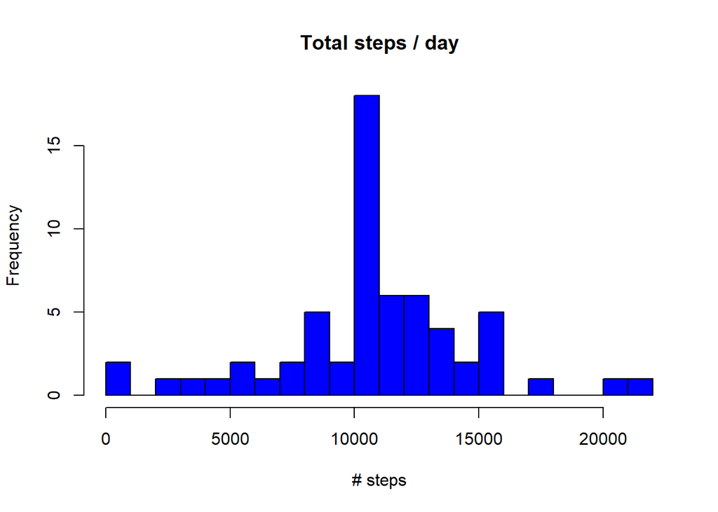

```r
#Histogram
hist(as.numeric(steps_per_day2$steps), breaks = 25, col = "blue", xlab = "# steps", main = "Total steps / day")
```

```r
#Mean and median
mean(steps_per_day2$steps)
```

```
## [1] 10766.19
```

```r
median(steps_per_day2$steps)
```

```
## [1] 10766.19
```

Difference between data with NAs and without NAs is 0 in mean, 1 in median.

## Are there differences in activity patterns between weekdays and weekends?

```r
filled_data$day <- as.factor(weekdays(filled_data$date))

filled_data$weekday <- ifelse(!(filled_data$day %in% c("Saturday", "Sunday")), TRUE, FALSE)

weekday <- filled_data[filled_data$weekday,]
steps_per_int_weekday <- aggregate(steps ~ interval, data = weekday, FUN=mean)

weekend <- filled_data[!filled_data$weekday,]
steps_per_int_weekend <- aggregate(steps ~ interval, data = weekend, FUN=mean)

colnames(steps_per_int_weekend) = c("interval", "avg_steps")
colnames(steps_per_int_weekday) = c("interval", "avg_steps")

steps_per_int_weekday$day <- "Weekday"
steps_per_int_weekend$day <- "Weekend"

weekData <- rbind(steps_per_int_weekend, steps_per_int_weekday)
weekData$day <- as.factor(weekData$day)

head(weekData)
```

```
##   interval   avg_steps     day
## 1        0 0.214622642 Weekend
## 2        5 0.042452830 Weekend
## 3       10 0.016509434 Weekend
## 4       15 0.018867925 Weekend
## 5       20 0.009433962 Weekend
## 6       25 3.511792453 Weekend
```

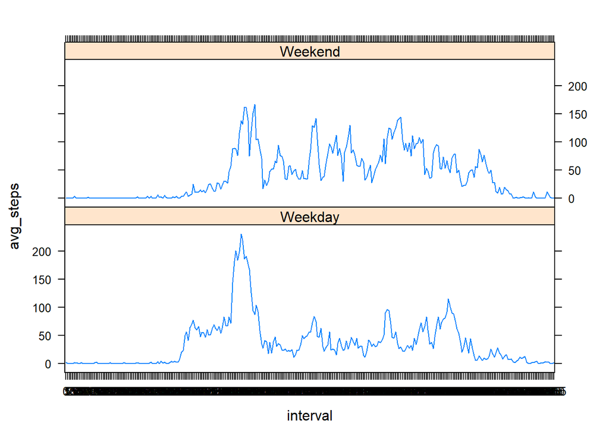

```r
library(lattice)
xyplot(avg_steps ~ interval | day, data = weekData, layout = c(1,2), type ="l")
```